# Exploratory Data Analysis on the Air Quality Dataset

### Load Packages

First things first, load the packages needed for further analysis.

```r
library(dplyr) # tools for data manipulation
```

```r
library(tibble) # tools for better data formatting than the traditional data frame
library(dlookr) # tools for data exploration
```

```r
library(htmltools) # tools for HTML generation and output
```

### Load Dataset

The dataset used is `airquality` which is already available in R, the `airquality` dataset is daily air quality measurements in New York, May to September 1973.

```r
# view data
head(airquality)
```

|  | Ozone | Solar.R | Wind | Temp | Month | Day |
| --- | --- | --- | --- | --- | --- | --- |
| 1 | 41 | 190 | 7.4 | 67 | 5 | 1 |
| 2 | 36 | 118 | 8.0 | 72 | 5 | 2 |
| 3 | 12 | 149 | 12.6 | 74 | 5 | 3 |
| 4 | 18 | 313 | 11.5 | 62 | 5 | 4 |
| 5 | NA | NA | 14.3 | 56 | 5 | 5 |
| 6 | 28 | NA | 14.9 | 66 | 5 | 6 |

### Data Diagnosis

#### *General Data Diagnosis*

The diagnosis of all variables in the `airquality` dataset.

```r
diagnose(airquality)
```

| variables | types | missing_count | missing_percent | unique_count | unique_rate |
| --- | --- | --- | --- | --- | --- |
| Ozone | integer | 37 | 24.183007 | 68 | 0.44444444 |
| Solar.R | integer | 7 | 4.575163 | 118 | 0.77124183 |
| Wind | numeric | 0 | 0.000000 | 31 | 0.20261438 |
| Temp | integer | 0 | 0.000000 | 40 | 0.26143791 |
| Month | integer | 0 | 0.000000 | 5 | 0.03267974 |
| Day | integer | 0 | 0.000000 | 31 | 0.20261438 |

- `variables` : Variable Names
- `types` : Data Type of the Variables
- `missing_count` : Number of Missing Values
- `missing_percent` : Percentage of Missing Values
- `unique_count` : Number of Unique Values
- `unique_rate` : Rate of Unique Value, Unique Count/Number of Observation

#### *Categorical Data Diagnosis*

The diagnosis of categorical variables in the `airquality` dataset.

```r
diagnose_category(airquality)
```

```
There is no categorical variable in the data or variable list.
```

The result is NULL because there’s no categorical variable in the `airquality` dataset.

#### *Numerical Data Diagnosis*

The diagnosis of numerical variables in the `airquality` dataset.

```r
diagnose_numeric(airquality)
```

| variables | min | Q1 | mean | median | Q3 | max | zero | minus | outlier |
| --- | --- | --- | --- | --- | --- | --- | --- | --- | --- |
| Ozone | 1.0 | 18.00 | 42.129310 | 31.5 | 63.25 | 168.0 | 0 | 0 | 2 |
| Solar.R | 7.0 | 115.75 | 185.931507 | 205.0 | 258.75 | 334.0 | 0 | 0 | 0 |
| Wind | 1.7 | 7.40 | 9.957516 | 9.7 | 11.50 | 20.7 | 0 | 0 | 3 |
| Temp | 56.0 | 72.00 | 77.882353 | 79.0 | 85.00 | 97.0 | 0 | 0 | 0 |
| Month | 5.0 | 6.00 | 6.993464 | 7.0 | 8.00 | 9.0 | 0 | 0 | 0 |
| Day | 1.0 | 8.00 | 15.803922 | 16.0 | 23.00 | 31.0 | 0 | 0 | 0 |

- `min` : Minimum Value
- `Q1` : 1/4 Quartile, 25th Percentile
- `mean` : Arithmetic Mean
- `median` : Median, 50th Percentile
- `Q3` : 3/4 Quartile, 75th Percentile
- `max` : Maximum Value
- `zero` : Number of Observations with a Value of 0
- `minus` : Number of Observations with Negative Numbers
- `outlier` : Number of Outliers

#### *Outlier Diagnosis*

```r
diagnose_outlier(airquality)
```

| variables | outliers_cnt | outliers_ratio | outliers_mean | with_mean | without_mean |
| --- | --- | --- | --- | --- | --- |
| Ozone | 2 | 1.307190 | 151.50000 | 42.129310 | 40.210526 |
| Solar.R | 0 | 0.000000 | NaN | 185.931507 | 185.931507 |
| Wind | 3 | 1.960784 | 19.73333 | 9.957516 | 9.762000 |
| Temp | 0 | 0.000000 | NaN | 77.882353 | 77.882353 |
| Month | 0 | 0.000000 | NaN | 6.993464 | 6.993464 |
| Day | 0 | 0.000000 | NaN | 15.803922 | 15.803922 |

#### *Outlier Plot*

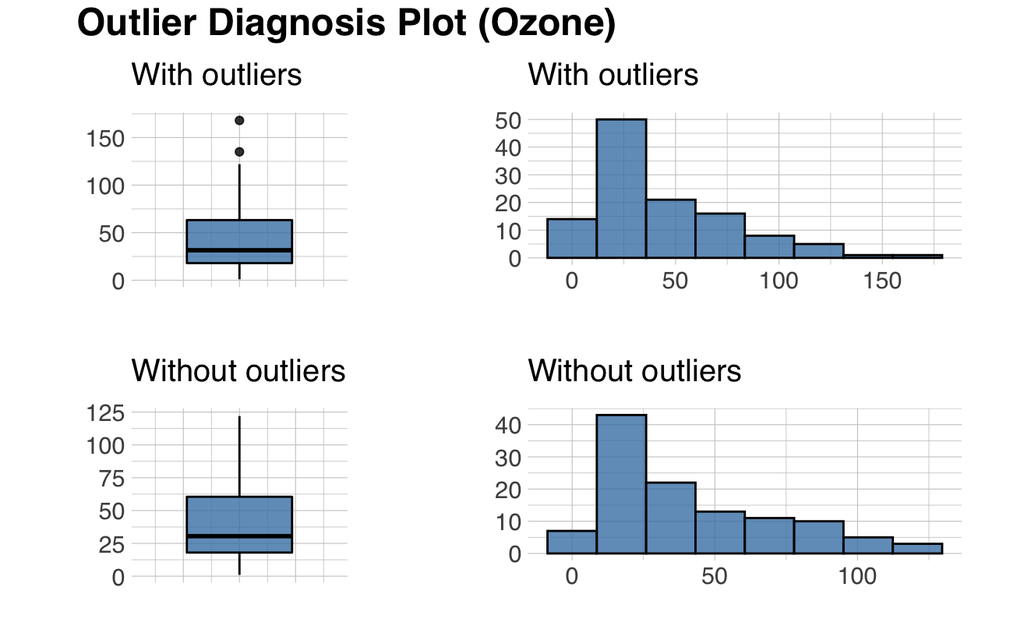

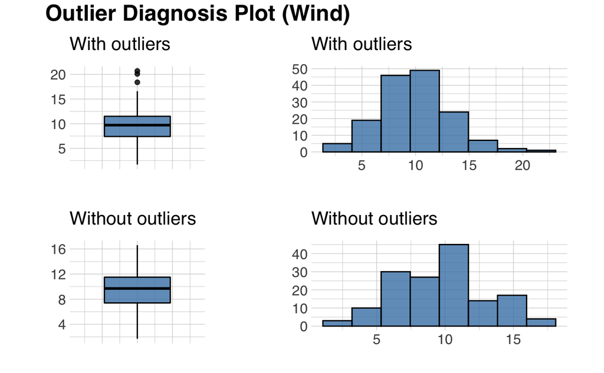

```r
airquality %>%
  plot_outlier(Ozone, Wind)
```

#### *Missing Value Intersection Plot*

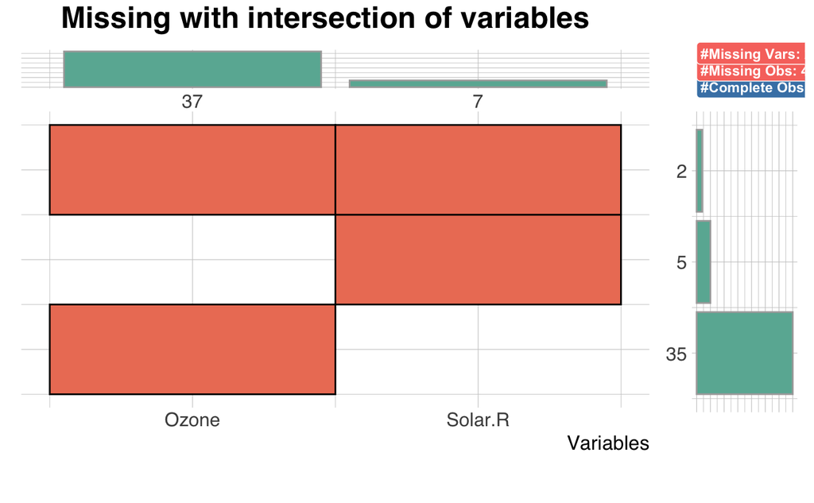

```r
plot_na_intersect(airquality)
```

### Data Diagnosis Made Easier!

The simple and fast way to perform data exploration, using `diagnose_web_report` from `dlookr` package.

```r
diagnose_web_report(airquality,output_file="airquality_Diagnosis_Report.html",output_dir="~/Downloads/")
```

airquality_Diagnosis_Report.html

### Descriptive Statistics

The deep dive into the `airquality` dataset’s statistics.

#### Summary

```r
summary(airquality)
```

```
     Ozone           Solar.R           Wind             Temp           Month
 Min.   :  1.00   Min.   :  7.0   Min.   : 1.700   Min.   :56.00   Min.   :5.000
 1st Qu.: 18.00   1st Qu.:115.8   1st Qu.: 7.400   1st Qu.:72.00   1st Qu.:6.000
 Median : 31.50   Median :205.0   Median : 9.700   Median :79.00   Median :7.000
 Mean   : 42.13   Mean   :185.9   Mean   : 9.958   Mean   :77.88   Mean   :6.993
 3rd Qu.: 63.25   3rd Qu.:258.8   3rd Qu.:11.500   3rd Qu.:85.00   3rd Qu.:8.000
 Max.   :168.00   Max.   :334.0   Max.   :20.700   Max.   :97.00   Max.   :9.000
 NA's   :37       NA's   :7
      Day
 Min.   : 1.0
 1st Qu.: 8.0
 Median :16.0
 Mean   :15.8
 3rd Qu.:23.0
 Max.   :31.0
```

#### Description

```r
describe(airquality)
```

| variable | n | na | mean | sd | se_mean | IQR | skewness | kurtosis | p00 | p01 | p05 | p10 | p20 | p25 | p30 | p40 | p50 | p60 | p70 | p75 | p80 | p90 | p95 | p99 | p100 |
| --- | --- | --- | --- | --- | --- | --- | --- | --- | --- | --- | --- | --- | --- | --- | --- | --- | --- | --- | --- | --- | --- | --- | --- | --- | --- |
| Ozone | 116 | 37 | 42.129310 | 32.987885 | 3.0628482 | 45.25 | 1.241796404 | 1.2903027 | 1.0 | 4.30 | 7.75 | 11.00 | 14.0 | 18.00 | 20 | 23.0 | 31.5 | 39.00 | 49.5 | 63.25 | 73.00 | 87.0 | 108.5 | 133.050 | 168.0 |
| Solar.R | 146 | 7 | 185.931507 | 90.058422 | 7.4532881 | 143.00 | -0.428044526 | -0.9684668 | 7.0 | 10.25 | 24.25 | 47.50 | 92.0 | 115.75 | 137 | 183.0 | 205.0 | 230.00 | 252.0 | 258.75 | 266.00 | 288.5 | 311.5 | 327.950 | 334.0 |
| Wind | 153 | 0 | 9.957516 | 3.523001 | 0.2848178 | 4.10 | 0.347817775 | 0.1114183 | 1.7 | 2.56 | 4.60 | 5.82 | 6.9 | 7.40 | 8 | 8.6 | 9.7 | 10.42 | 11.5 | 11.50 | 12.96 | 14.9 | 15.5 | 19.216 | 20.7 |
| Temp | 153 | 0 | 77.882353 | 9.465270 | 0.7652217 | 13.00 | -0.377884464 | -0.4035054 | 56.0 | 57.00 | 60.20 | 64.20 | 69.0 | 72.00 | 74 | 76.8 | 79.0 | 81.00 | 83.0 | 85.00 | 86.00 | 90.0 | 92.0 | 94.960 | 97.0 |
| Month | 153 | 0 | 6.993464 | 1.416522 | 0.1145191 | 2.00 | -0.002391498 | -1.2975830 | 5.0 | 5.00 | 5.00 | 5.00 | 5.4 | 6.00 | 6 | 6.8 | 7.0 | 7.20 | 8.0 | 8.00 | 8.00 | 9.0 | 9.0 | 9.000 | 9.0 |
| Day | 153 | 0 | 15.803922 | 8.864520 | 0.7166540 | 15.00 | 0.002651853 | -1.1988345 | 1.0 | 1.00 | 2.00 | 4.00 | 7.0 | 8.00 | 10 | 13.0 | 16.0 | 19.00 | 22.0 | 23.00 | 25.00 | 28.0 | 29.4 | 31.000 | 31.0 |

#### Normality Checking

```r
normality(airquality)
```

| vars | statistic | p_value | sample |
| --- | --- | --- | --- |
| Ozone | 0.8786660 | 2.789602e-08 | 153 |
| Solar.R | 0.9418340 | 9.491956e-06 | 153 |
| Wind | 0.9857498 | 1.177928e-01 | 153 |
| Temp | 0.9761730 | 9.319356e-03 | 153 |
| Month | 0.8880449 | 2.258252e-09 | 153 |
| Day | 0.9531252 | 5.047663e-05 | 153 |

#### Normality Plot

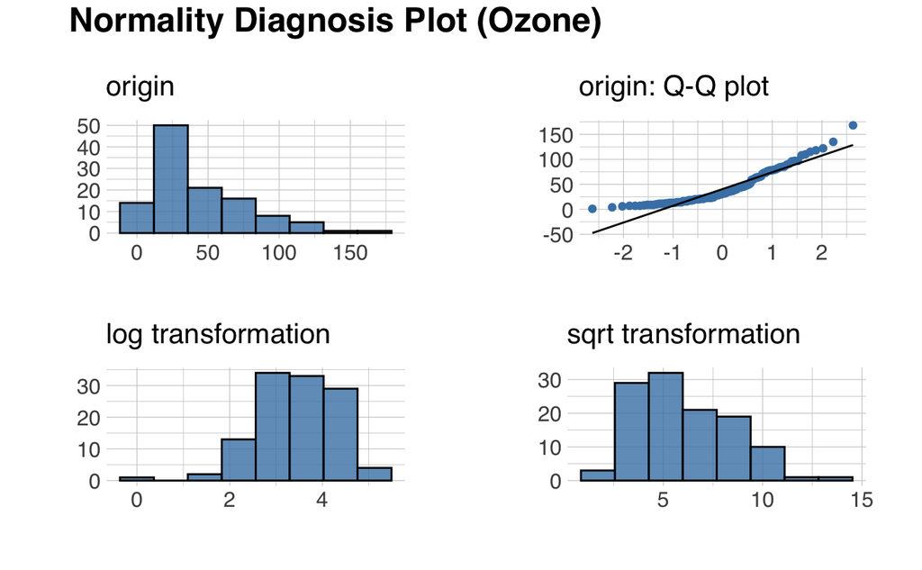

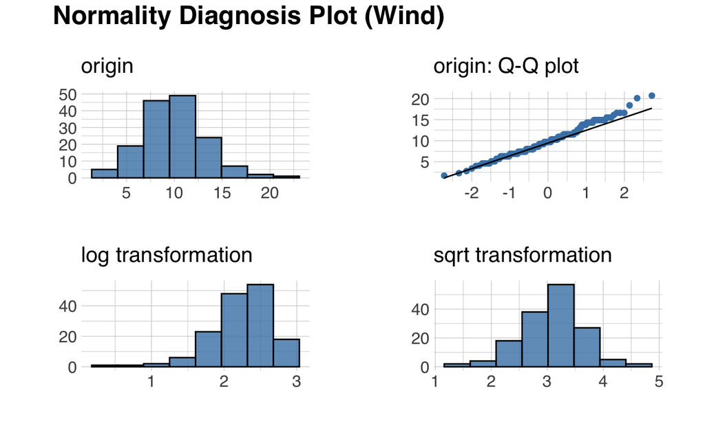

```r
airquality %>%
  plot_normality(Ozone, Wind)
```

#### Correlation Matrix

```r
correlate(airquality)
```

| var1 | var2 | coef_corr |
| --- | --- | --- |
| Solar.R | Ozone | 0.348341693 |
| Wind | Ozone | -0.601546530 |
| Temp | Ozone | 0.698360342 |
| Month | Ozone | 0.164519314 |
| Day | Ozone | -0.013225647 |
| Ozone | Solar.R | 0.348341693 |
| Wind | Solar.R | -0.056791666 |
| Temp | Solar.R | 0.275840271 |
| Month | Solar.R | -0.075300764 |
| Day | Solar.R | -0.150274979 |

[output cut: 20 more lines]

#### Correlation Plot

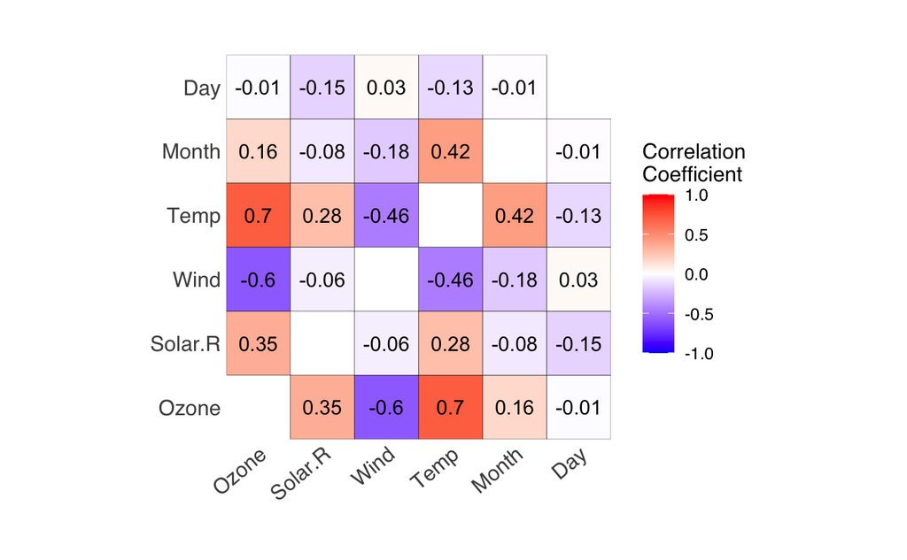

```r
plot_correlate(airquality)
```

### Data Exploration Made Easier!

The simple and fast way to perform data exploration, using `eda_web_report` from `dlookr` package.

```r
eda_web_report(airquality,output_file="airquality_Exploration_Report.html",output_dir="~/Downloads/")
```

airquality_Exploration_Report.html

### Data Transformation

The data transformation is used according to the needs.

#### Handling Missing Values

Missing values can be handeled by two methods:

##### Remove Missing Values

```r
NROW(airquality$Ozone)
```

```
[1] 153
```

```r
x <- na.omit(airquality$Ozone)
NROW(x)
```

```
[1] 116
```

##### Impute Missing Values

Methods:

- `mean` : Arithmetic Mean
- `median` : Median
- `mode` : Mode
- `knn` : K-nearest Neighbors (target variable must be specified)
- `rpart` : Recursive Partitioning and Regression Trees (target variable must be specified)
- `mice` : Multivariate Imputation by Chained Equations (target variable must be specified, random seed must be set)

```r
ozone_impute <- imputate_na(airquality, Ozone, method = "mean")
summary(ozone_impute)
```

```
Impute missing values with mean

* Information of Imputation (before vs after)
           Original Imputation
n        116.000000 153.000000
na        37.000000   0.000000
mean      42.129310  42.129310
sd        32.987885  28.693372
se_mean    3.062848   2.319722
IQR       45.250000  25.000000
skewness   1.241796   1.421624
kurtosis   1.290303   2.643199
p00        1.000000   1.000000
p01        4.300000   5.040000
p05        7.750000   9.000000
p10       11.000000  12.200000
p20       14.000000  18.000000
p25       18.000000  21.000000
p30       20.000000  23.000000
p40       23.000000  33.600000
p50       31.500000  42.129310
p60       39.000000  42.129310
p70       49.500000  42.129310
p75       63.250000  46.000000
p80       73.000000  60.200000
p90       87.000000  81.600000
p95      108.500000  97.000000
p99      133.050000 128.240000
p100     168.000000 168.000000
```

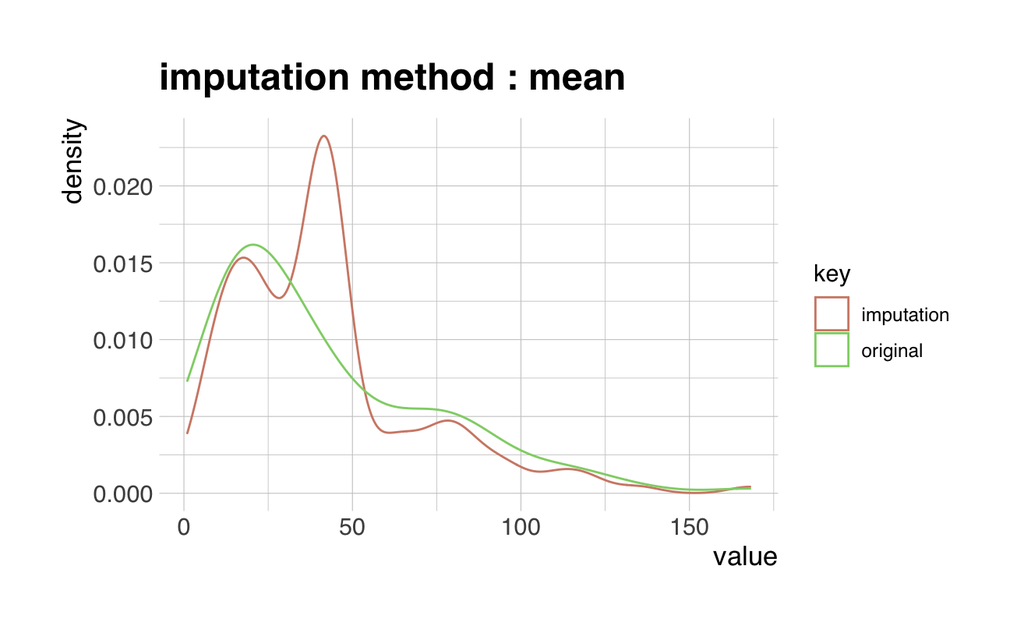

```r
plot(ozone_impute)
```

#### Handling Outliers

Outliers can be handeled by two methods:

##### Remove Outliers

```r
Q1 <- quantile(airquality$Wind, .25)
Q3 <- quantile(airquality$Wind, .75)
IQR <- IQR(airquality$Wind)
no_outliers <- subset(airquality, airquality$Wind > (Q1 - 1.5*IQR) & airquality$Wind < (Q3 + 1.5*IQR))
NROW(no_outliers)
```

```
[1] 150
```

##### Impute Outliers

Methods:

- `mean` : Arithmetic Mean
- `median` : Median
- `mode` : Mode
- `capping` : Impute the Upper Outliers with 95th Percentile and Impute the Bottom Outliers with 5th Percentile

```r
out_wind <- imputate_outlier(airquality, Wind, method = "capping")
summary(out_wind)
```

```
Impute outliers with capping

* Information of Imputation (before vs after)
            Original  Imputation
n        153.0000000 153.0000000
na         0.0000000   0.0000000
mean       9.9575163   9.8745098
sd         3.5230014   3.3325652
se_mean    0.2848178   0.2694219
IQR        4.1000000   4.1000000
skewness   0.3478178   0.0590653
kurtosis   0.1114183  -0.5478332
p00        1.7000000   1.7000000
p01        2.5600000   2.5600000
p05        4.6000000   4.6000000
p10        5.8200000   5.8200000
p20        6.9000000   6.9000000
p25        7.4000000   7.4000000
p30        8.0000000   8.0000000
p40        8.6000000   8.6000000
p50        9.7000000   9.7000000
p60       10.4200000  10.4200000
p70       11.5000000  11.5000000
p75       11.5000000  11.5000000
p80       12.9600000  12.9600000
p90       14.9000000  14.9000000
p95       15.5000000  15.5000000
p99       19.2160000  16.6000000
p100      20.7000000  16.6000000
```

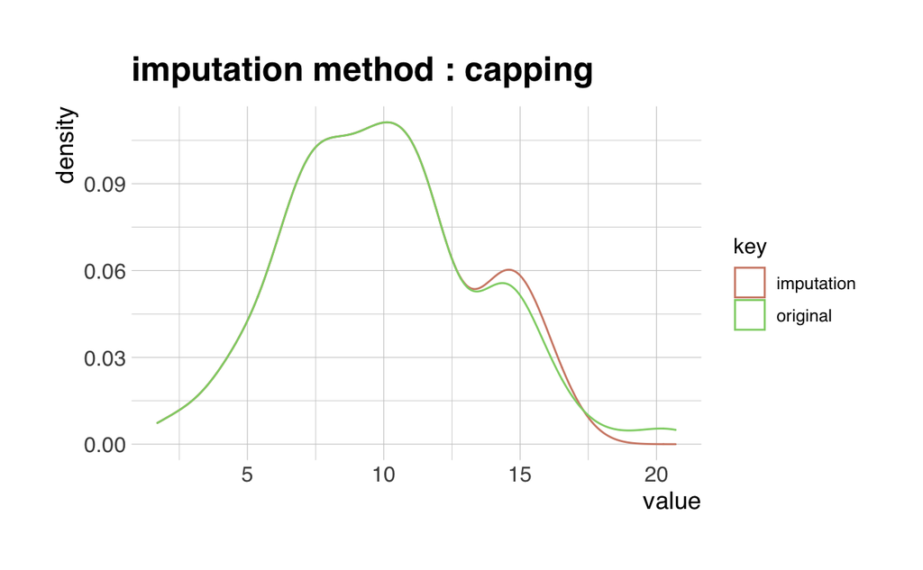

```r
plot(out_wind)
```

#### Standardization

Methods:

- `zscore` : Z-score Transformation, (x - mu) / sigma
- `minmax` : MinMax Transformation, (x - min) / (max - min)

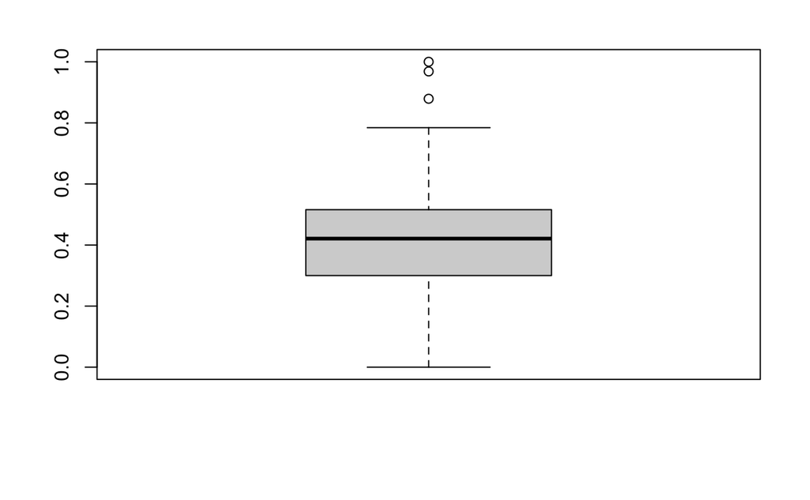

```r
air_trans<- transform(airquality$Wind, method = "minmax")
boxplot(air_trans)
```

#### Resolving Skewness

Methods:

- `log` : Log Transformation, log(x)
- `log+1` : Tog Transformation, log(x + 1), used for values that contain 0
- `sqrt` : Square Root Transformation
- `1/x` : 1 / x Transformation
- `x^2` : X^2 Transformation
- `x^3` : X^3 Transformation

```r
Ozone_log = transform(airquality$Ozone, method = "log")
summary(Ozone_log)
```

```
* Resolving Skewness with log

* Information of Transformation (before vs after)
           Original Transformation
n        116.000000   116.00000000
na        37.000000    37.00000000
mean      42.129310     3.41851510
sd        32.987885     0.86547454
se_mean    3.062848     0.08035729
IQR       45.250000     1.25670006
skewness   1.241796    -0.56230968
kurtosis   1.290303     0.93250632
p00        1.000000     0.00000000
p01        4.300000     1.44711413
p05        7.750000     2.04605869
p10       11.000000     2.39789527
p20       14.000000     2.63905733
p25       18.000000     2.89037176
p30       20.000000     2.99573227
p40       23.000000     3.13549422
p50       31.500000     3.44986155
p60       39.000000     3.66356165
p70       49.500000     3.90192165
p75       63.250000     4.14707182
p80       73.000000     4.29045944
p90       87.000000     4.46564381
p95      108.500000     4.68671851
p99      133.050000     4.89008672
p100     168.000000     5.12396398
```

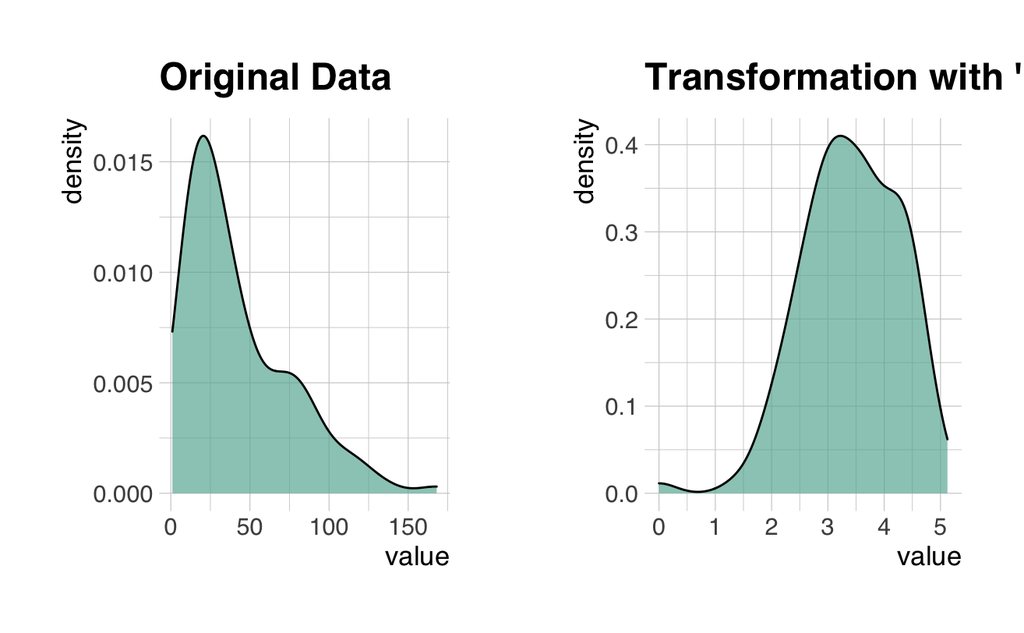

```r
plot(Ozone_log)
```